# Cleaned Image Rendering with Models

```r
library(rvest) #webscraping package
library(jpeg) #convert scraped images to jpeg
library(xml2) #convert the xml from webpage into a list
library(dplyr)
library(EBImage)
library(magick)
library(janitor)
library(rvest)


#library(pdftools) # Reads pdf names into text strings
library(tm) # Text cleaning for large corpa similar to tidytext it can help with cleaning and tokenizing
library(quanteda) # Text cleaning for large corpa similar to tidytext tokenizing
library(tidytext) # For analysis of text in a tidy manner including sentiment data
library(textstem) # For stemming and lemmatizing text
library(gutenbergr) # Project Gutenberg books
library(wordcloud) # For world cloud
#
library(lsa) # For latent semantic analysis
library(stm) # For structural topic modeling
library(uwot) # For umap dimensionality reduction
library(text2vec) # For cosine similarity -
library(kernlab) # For kernel-based cannonical correlation analysis
library(rPref) # For pareto frontier
library(DT) # For interactive data tables
library(textdata) # Database of lexicon and embeddings
#
library(knitr)
library(ggrepel)
library(caret) # For predictive model fitting
library(tidyverse)
library(patchwork)
#biocLite("EBImage")
library (EBImage)


library(tidyverse)
library(kernlab)
library(dbscan)
library(clValid) # For selecting cluster method and number of clusters
library(factoextra) # for cluster fitting and visualization
library(uwot) # For UMAP dimensionality reduction
library(patchwork) # For arranging multiple plots

set.seed(888) # To ensure consistent results from non-deterministic procedures
rm(list = ls()) # Removes all variables
```

#Data Collection and Manipulation

```r
simple= read_html("https://gailambrosius.com/explore-flavors/learn-about-the-flavors")
info_links = as_list(html_nodes(simple, ".popup")) #got all of the names of the chocolates
```

```r
attribs = list("width", "height","src", ".class", "alt", "srcset", "sizes")
#attribs[[1]]

d = c(1:length(info_links))
c_list = c()
width = c()
height =c()
src = c()
alt = c()
srcset = c()
sizes = c()
descr_list= c()

for(j in d){
    chocolate_img = info_links[j][[1]]$img
    chocolate_name = info_links[j][[1]]$div[[1]][1]
    # append(c_list, chocolate_name)
    descr_link = attr(info_links[j][[1]], "href")

  # identify = c(chocolate_name)
  for(i in attribs){
    # identify =c(identify, attr(chocolate_img, i))
    # if (i == "width"){
    #   width = c(width,attr(chocolate_img, i) )
    # }
    # else if (i == "height"){
    #   height = c(height,attr(chocolate_img, i) )
    # }
    if (i == "src"){
      src = c(src,attr(chocolate_img, i) )
    }
#     else if (i == "src"){
#       src = c(src,attr(chocolate_img, i) )
#     }
  }
# df = do.call(rbind.data.frame, identify
c_list =c(c_list, chocolate_name)
descr_list = c(descr_list, descr_link)

}
print(descr_list)
df <- data.frame (
                  name = c_list,
                  image_url = src,
                  d_list = descr_list
                  )
```

```r
reader <- function(url) {

  simple= read_html(url)

 x =  simple %>%
  html_nodes("p") %>%
  html_text()

 # print(typeof(x[1]))
 # print(typeof(x[2]))
 print(paste(x[1], x[2]), sep = " ")

}
```

```r
df[3,1] = "Cinnamon and Cayenne"
```

```r
df$d_list <-as.character(df$d_list)
df["text"] = sapply(df$d_list, reader)
df$image_url <-as.character(df$image_url)
```

## Image Clustering from John

## Compute features for images

These features describe images such as the data in the Wisconsin Cancer data. These are morphological and texture properties of images

computeFeatures: Compute object features

#Collect Data

```r
#this gets all of the necessary jpegs
#for (i in 1:nrow(df))
df_test = data.frame()


for (i in 1:16)
{
  choc_name = df["name"][i,]
  print(choc_name)
  url = df["image_url"][i,]
  #print(url)
  download.file(url, paste(choc_name,".jpeg", sep=""), mode = "wb")
  file_name = paste(choc_name,".jpeg", sep="")
  print(file_name) #Blueberry, Caramel, Cinnamon

  #trycatch(Image, erro)

  Image <- readImage(file_name) #something is up with cinnamon





  Image3<-getFrame(Image,2) #changing the frame you grab does slightly change the results
  x = thresh(Image3, w=45, h=45, offset=0.05)
  x = opening(x, makeBrush(11, shape='diamond'))
  x = bwlabel(x)
  fts = computeFeatures.shape(x) #computing morphological and texture features of image objects
#the .shape compute features that


morph = fts %>%
  as_tibble() %>%
  mutate(across(.cols = everything(), list(mean = mean, sd = sd))) %>%
  mutate(count = n()) %>%
  select(7:19)
morph = head(morph, 1)
morph[is.na(morph)] = 0

morph$name = choc_name

#print(morph)

text <- computeFeatures.haralick(x, Image3)#the .shape compute features that

text = as.data.frame(text)

haralickFeatures = text %>%
  as_tibble() %>%
  mutate(across(.cols = everything(), list(mean = mean, sd = sd))) %>%
  select(27:78) #h.asm.s1_mean should be the first one
haralickFeatures  = head(haralickFeatures, 1) #remove the first row since it duplicates

haralickFeatures$name = choc_name

haralickFeatures[is.na(haralickFeatures)] = 0
#print(haralickFeatures)

final = merge(haralickFeatures, morph)

df_test = rbind(df_test, final)

#print(final)

#tada = rbind(final, df)
#rbind(df)
# row_select = df[i,]
#
# okkk = merge(final, row_select)
#
# #print(okkk)
#
#
# df_test = rbind(df_test, okkk)
#
# print(df_test)

}
```

```
[1] "Blueberry"
```

```
[1] "Blueberry.jpeg"
[1] "Caramel Sprinkled With Grey Salt"
```

```
[1] "Caramel Sprinkled With Grey Salt.jpeg"
[1] "Cinnamon and Cayenne"
```

```
[1] "Cinnamon and Cayenne.jpeg"
[1] "Cognac"
```

```
[1] "Cognac.jpeg"
[1] "Cointreau"
```

```
[1] "Cointreau.jpeg"
```

```
[1] "Earl Grey"
```

```
[1] "Earl Grey.jpeg"
[1] "Espresso"
```

```
[1] "Espresso.jpeg"
[1] "Featured Single Origin"
```

```
[1] "Featured Single Origin.jpeg"
[1] "Jasmine"
```

```
[1] "Jasmine.jpeg"
[1] "Lemongrass with Ginger"
```

```
[1] "Lemongrass with Ginger.jpeg"
[1] "Lucille’s Vanilla"
```

```
[1] "Lucille’s Vanilla.jpeg"
[1] "Machu Picchu"
```

```
[1] "Machu Picchu.jpeg"
[1] "Raspberry"
```

```
[1] "Raspberry.jpeg"
[1] "Rose"
```

```
[1] "Rose.jpeg"
[1] "Shiitake Mushroom"
```

```
[1] "Shiitake Mushroom.jpeg"
[1] "Sweet Curry With Saffron"
```

```
[1] "Sweet Curry With Saffron.jpeg"
```

```r
df_test
```

| name | h.asm.s1_mean | h.asm.s1_sd | h.con.s1_mean | h.con.s1_sd | h.cor.s1_mean | h.cor.s1_sd | h.var.s1_mean | h.var.s1_sd | h.idm.s1_mean | h.idm.s1_sd | h.sav.s1_mean | h.sav.s1_sd | h.sva.s1_mean | h.sva.s1_sd | h.sen.s1_mean | h.sen.s1_sd | h.ent.s1_mean | h.ent.s1_sd | h.dva.s1_mean | h.dva.s1_sd | h.den.s1_mean | h.den.s1_sd | h.f12.s1_mean | h.f12.s1_sd | h.f13.s1_mean | h.f13.s1_sd | h.asm.s2_mean | h.asm.s2_sd | h.con.s2_mean | … |
| --- | --- | --- | --- | --- | --- | --- | --- | --- | --- | --- | --- | --- | --- | --- | --- | --- | --- | --- | --- | --- | --- | --- | --- | --- | --- | --- | --- | --- | --- | --- |
| Blueberry | 0.4650352 | 0.0000000 | 0.3962407 | 0.0000000 | 0.7120283 | 0.00000000 | 1.687986 | 0.0000000 | 0.9201883 | 0.0000000 | 63.17812 | 0.000000 | 3933.989 | 0.0000 | 0.4753815 | 0.0000000 | 0.5441688 | 0.0000000 | 0.3962407 | 0.0000000 | 0.2220162 | 0.0000000 | 0.4441091 | 0.00000000 | 0.5167506 | 0.000000000 | 0.4335735 | 0.0000000 | 0.5064112 | … |
| Caramel Sprinkled With Grey Salt | 0.6519246 | 0.0000000 | 0.2712311 | 0.0000000 | 0.5121484 | 0.00000000 | 1.277985 | 0.0000000 | 0.9335304 | 0.0000000 | 63.63073 | 0.000000 | 4009.132 | 0.0000 | 0.3196581 | 0.0000000 | 0.3726719 | 0.0000000 | 0.2712311 | 0.0000000 | 0.1916506 | 0.0000000 | 0.2882359 | 0.00000000 | 0.3434363 | 0.000000000 | 0.6423486 | 0.0000000 | 0.3689976 | … |
| Cinnamon and Cayenne | 0.4350060 | 0.0000000 | 0.5046352 | 0.0000000 | 0.5808865 | 0.00000000 | 1.602027 | 0.0000000 | 0.9037159 | 0.0000000 | 63.20407 | 0.000000 | 3934.762 | 0.0000 | 0.4915609 | 0.0000000 | 0.5670687 | 0.0000000 | 0.5046352 | 0.0000000 | 0.2506964 | 0.0000000 | 0.3520858 | 0.00000000 | 0.4639023 | 0.000000000 | 0.3887847 | 0.0000000 | 0.7036604 | … |
| Cognac | 0.2617993 | 0.3598517 | 1.4858385 | 1.1886797 | 0.5716952 | 0.12988743 | 2.974248 | 1.5395553 | 0.7075785 | 0.1888278 | 55.75033 | 10.197293 | 3099.438 | 1104.5555 | 0.7993774 | 0.4382437 | 1.0778952 | 0.6331617 | 1.4858385 | 1.1886797 | 0.4320965 | 0.2017769 | 0.1705348 | 0.02064866 | 0.4074925 | 0.141367310 | 0.2533858 | 0.3566421 | 2.2049962 | … |
| Cointreau | 0.3598790 | 0.4144990 | 3.7543057 | 4.6308017 | 0.5866149 | 0.11199620 | 4.926291 | 4.5373462 | 0.7163363 | 0.2799473 | 61.41360 | 2.931768 | 3701.551 | 405.1684 | 0.7205104 | 0.5174466 | 0.9818406 | 0.7871549 | 3.7543057 | 4.6308017 | 0.4923336 | 0.3630720 | 0.2006974 | 0.09138851 | 0.3988938 | 0.070208483 | 0.3357334 | 0.4140952 | 5.9144779 | … |
| Earl Grey | 0.3543559 | 0.4606830 | 2.0240593 | 2.4065757 | 0.6654508 | 0.09233177 | 4.660806 | 4.6070847 | 0.7380494 | 0.2666715 | 59.06628 | 6.419812 | 3434.401 | 809.1158 | 0.7848377 | 0.6590930 | 1.0597008 | 0.9666805 | 2.0240593 | 2.4065757 | 0.4250002 | 0.3079251 | 0.2553481 | 0.03073296 | 0.4726844 | 0.191080047 | 0.3394783 | 0.4457243 | 4.0848807 | … |
| Espresso | 0.4727813 | 0.0000000 | 0.3624800 | 0.0000000 | 0.6994448 | 0.00000000 | 1.603017 | 0.0000000 | 0.9335498 | 0.0000000 | 63.19844 | 0.000000 | 3939.273 | 0.0000 | 0.4511464 | 0.0000000 | 0.5070720 | 0.0000000 | 0.3624800 | 0.0000000 | 0.1954195 | 0.0000000 | 0.5001004 | 0.00000000 | 0.5356338 | 0.000000000 | 0.4479563 | 0.0000000 | 0.5143580 | … |
| Featured Single Origin | 0.2574656 | 0.2624347 | 0.6302433 | 0.5631773 | 0.7030144 | 0.02495475 | 2.024850 | 0.8620411 | 0.8051854 | 0.1874182 | 55.23671 | 11.235785 | 3044.716 | 1261.1000 | 0.7014233 | 0.3529033 | 0.8718009 | 0.5259946 | 0.6302433 | 0.5631773 | 0.3089946 | 0.1792793 | 0.3698366 | 0.19615716 | 0.5321144 | 0.007547586 | 0.2439869 | 0.2544521 | 1.5407584 | … |
| Jasmine | 0.4730112 | 0.0000000 | 0.3353174 | 0.0000000 | 0.7228100 | 0.00000000 | 1.604851 | 0.0000000 | 0.9320452 | 0.0000000 | 63.18923 | 0.000000 | 3937.009 | 0.0000 | 0.4602438 | 0.0000000 | 0.5182271 | 0.0000000 | 0.3353174 | 0.0000000 | 0.1977291 | 0.0000000 | 0.5046919 | 0.00000000 | 0.5433100 | 0.000000000 | 0.4473820 | 0.0000000 | 0.5114302 | … |
| Lemongrass with Ginger | 0.1950629 | 0.2529375 | 3.0006820 | 2.7118763 | 0.5699389 | 0.13961608 | 4.361099 | 3.3609478 | 0.6601144 | 0.2493749 | 60.47273 | 2.812058 | 3571.015 | 371.4043 | 0.8593639 | 0.3948689 | 1.1897860 | 0.6503219 | 3.0006820 | 2.7118763 | 0.5077495 | 0.2945438 | 0.2614182 | 0.22364586 | 0.4722334 | 0.067467100 | 0.2085867 | 0.2182038 | 5.2784262 | … |

[output cut: 6 more lines]

```r
NA
NA
```

##Unsupverised Learning Set Up

```r
## Prepare data with removing NA and scaling
scaled.df = df_test %>%
  drop_na() %>%  # Removes rows with missing data
  select(-name) %>%
  scale() %>% as.data.frame()
```

## Identify best method and number clusters with *internal* metrics

clValid makes it possible to fit a rnage of clusters (nClust) using a range of methods (clMethods) and evaluate with internal and stability metrics.

clValid identifies the best combination of method and number of clusters using internal metrics of connectivity, silhouette, and Dunn. Connectivity should be minimized and the others maximized.

```r
## Internal metrics
internal.cl = clValid(scaled.df,
                  nClust = 2:10,
                  clMethods = c("kmeans","pam", "agnes", "diana"),
                  maxitems = 1000, # specifies the number of cases considered
                  validation = "internal")
```

```
rownames for data not specified, using 1:nrow(data)
```

```r
## View internal metrics
summary(internal.cl)
```

```
Clustering Methods:
 kmeans pam agnes diana

Cluster sizes:
 2 3 4 5 6 7 8 9 10

Validation Measures:
                           2       3       4       5       6       7       8       9      10

kmeans Connectivity   5.2778 11.7754 18.9135 20.2468 23.2968 24.0468 27.4968 29.6635 31.1635
       Dunn           0.8955  0.4248  0.7193  0.7298  0.7635  0.8001  0.7399  0.8198  1.1093
       Silhouette     0.5998  0.4373  0.4563  0.4023  0.3946  0.3751  0.2825  0.2861  0.2709
pam    Connectivity   5.2778 14.5361 17.3040 16.6540 20.0373 23.4873 26.2706 28.8302 31.1635
       Dunn           0.8955  0.5008  0.5266  0.6289  0.6289  0.5156  0.5832  0.7588  1.1093
       Silhouette     0.5998  0.4442  0.4126  0.3665  0.3292  0.2366  0.2413  0.2507  0.2709
agnes  Connectivity   5.2778 11.7754 18.9135 20.2468 22.2802 24.0468 27.4968 29.6635 31.1635
       Dunn           0.8955  0.4248  0.7193  0.7298  0.7499  0.8001  0.7399  0.8198  1.1093
       Silhouette     0.5998  0.4373  0.4563  0.4023  0.3804  0.3751  0.2825  0.2861  0.2709
diana  Connectivity   5.2778 14.4778 18.9135 20.2468 22.2802 24.0468 27.4968 29.6635 31.1635
       Dunn           0.8955  0.4837  0.7193  0.7298  0.7499  0.8001  0.7399  0.8198  1.1093
       Silhouette     0.5998  0.4499  0.4563  0.4023  0.3804  0.3751  0.2825  0.2861  0.2709

Optimal Scores:
```

|  | Score | Method | Clusters |
| --- | --- | --- | --- |
| Connectivity | 5.2778 | kmeans | 2 |
| Dunn | 1.1093 | kmeans | 10 |
| Silhouette | 0.5998 | kmeans | 2 |

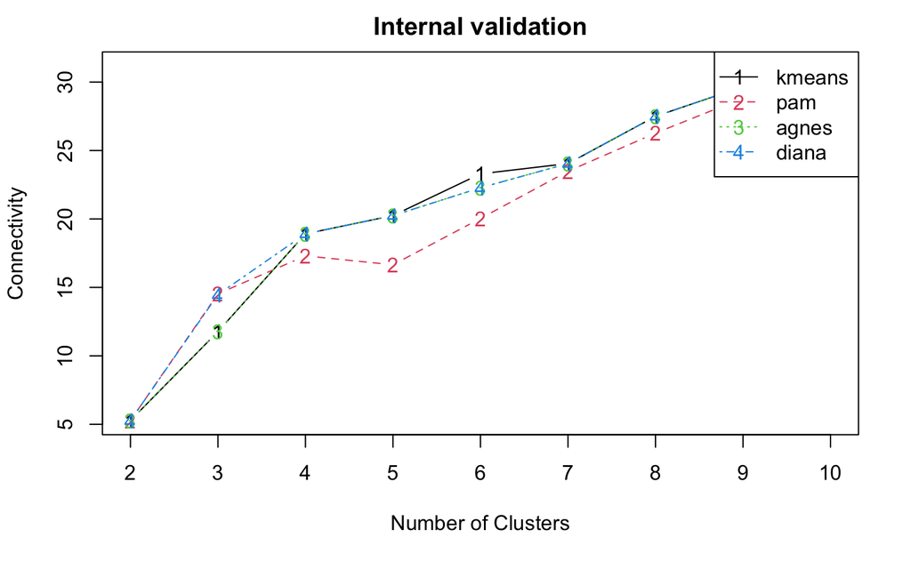

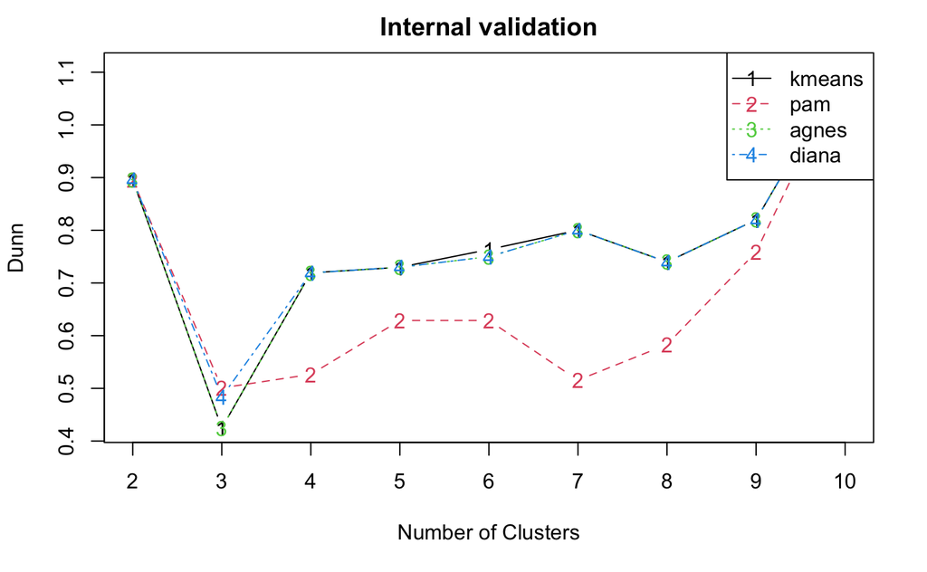

```r
plot(internal.cl)
```

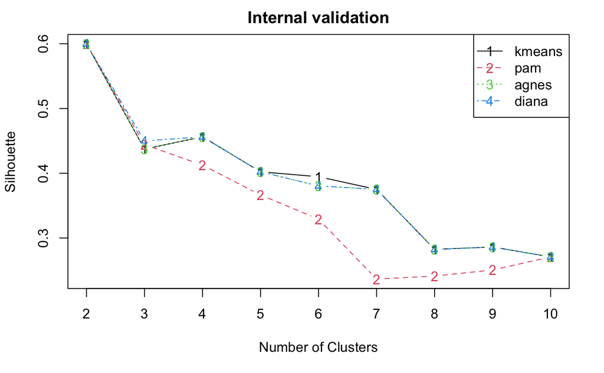

```r
NA
```

## Identify best method and number clusters with *stability* metrics

Stability metrics estimate how consistent the clustering solution. Ideally you would get the same items belonging to the same clusters if the analysis is repeated.

```r
## Stability  metrics
stability.cl = clValid(scaled.df,
                nClust = 2:10,
                clMethods = c("kmeans","pam", "agnes", "diana"),
                maxitems = 1700, # specifies the number of cases considered
                validation = "stability")
```

```
rownames for data not specified, using 1:nrow(data)
```

```r
## View stability metrics
summary(stability.cl)
```

```
Clustering Methods:
 kmeans pam agnes diana

Cluster sizes:
 2 3 4 5 6 7 8 9 10

Validation Measures:
                 2      3      4      5      6      7      8      9     10

kmeans APN  0.0000 0.0000 0.0000 0.0027 0.0051 0.0279 0.0359 0.0083 0.0032
       AD   4.9927 4.2156 3.3742 2.9554 2.5171 2.1797 1.7539 1.2540 0.8809
       ADM  0.0000 0.0000 0.0000 0.0232 0.0556 0.2098 0.3556 0.0951 0.0162
       FOM  0.5171 0.4692 0.3853 0.3769 0.3726 0.3464 0.3297 0.2949 0.1778
pam    APN  0.0000 0.0087 0.0087 0.0042 0.0081 0.0031 0.0058 0.0192 0.0000
       AD   4.9927 4.1574 3.5065 3.1015 2.6857 2.1650 1.6957 1.3284 0.8740
       ADM  0.0000 0.0881 0.0849 0.0319 0.0794 0.0365 0.0567 0.1699 0.0000
       FOM  0.5171 0.4610 0.4219 0.4014 0.3939 0.3689 0.3225 0.2910 0.1654
agnes  APN  0.0000 0.0010 0.0163 0.0160 0.0135 0.0256 0.0308 0.0173 0.0000
       AD   4.9927 4.2215 3.4362 3.0096 2.5907 2.1940 1.7606 1.3095 0.8740
       ADM  0.0000 0.0142 0.1591 0.1593 0.1584 0.2163 0.3445 0.2082 0.0000
       FOM  0.5171 0.4700 0.3979 0.3906 0.3755 0.3535 0.3416 0.3218 0.1654
diana  APN  0.0000 0.0000 0.0000 0.0064 0.0087 0.0000 0.0051 0.0000 0.0000
       AD   4.9927 4.1287 3.3742 2.9788 2.5576 2.0884 1.6146 1.2045 0.8740
       ADM  0.0000 0.0000 0.0000 0.0708 0.0920 0.0000 0.0621 0.0000 0.0000
       FOM  0.5171 0.4554 0.3853 0.3800 0.3687 0.3128 0.3046 0.2423 0.1654

Optimal Scores:
```

|  | Score | Method | Clusters |
| --- | --- | --- | --- |
| APN | 0.0000 | kmeans | 2 |
| AD | 0.8740 | pam | 10 |
| ADM | 0.0000 | kmeans | 2 |
| FOM | 0.1654 | pam | 10 |

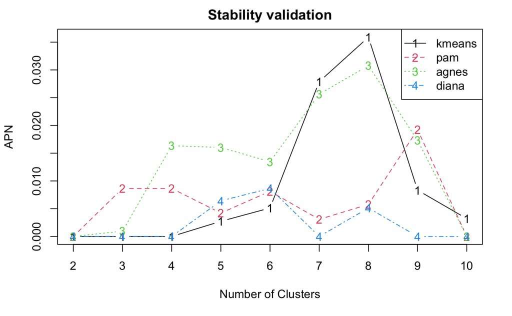

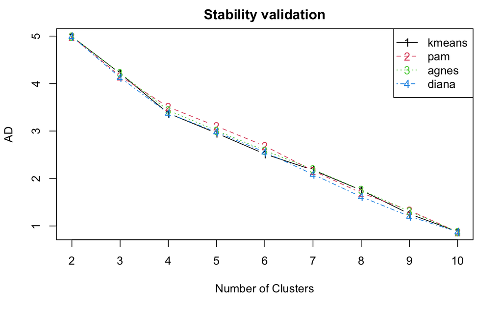

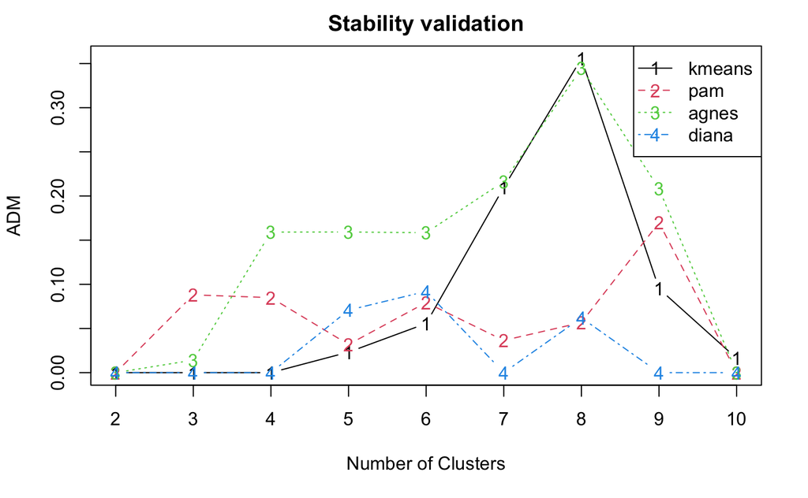

```r
plot(stability.cl)
```

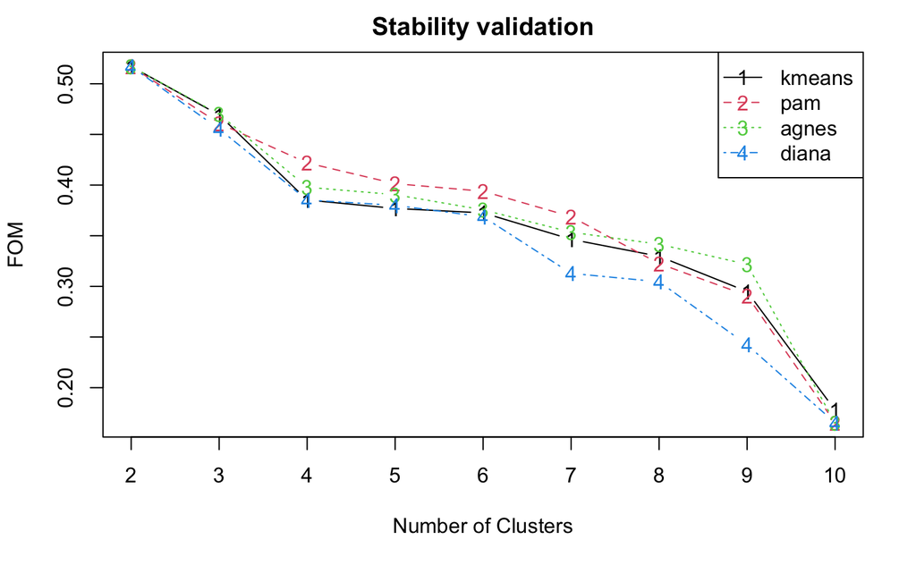

```r
NA
```

The gap metric measures the total intracluster variation relative to its expected value if there was no clustering.

```r
wine.agnes = eclust(scaled.df,
                    FUNcluster = "kmeans",
                    nboot = 200,
                    seed = 888)

# Silhouette plot
fviz_silhouette(wine.agnes)
```

[output not shown]

## Fit and visualize best solution

|  | cluster | size | ave.sil.width |
| --- | --- | --- | --- |
| 1 | 1 | 7 | 0.78 |
| 2 | 2 | 9 | 0.46 |

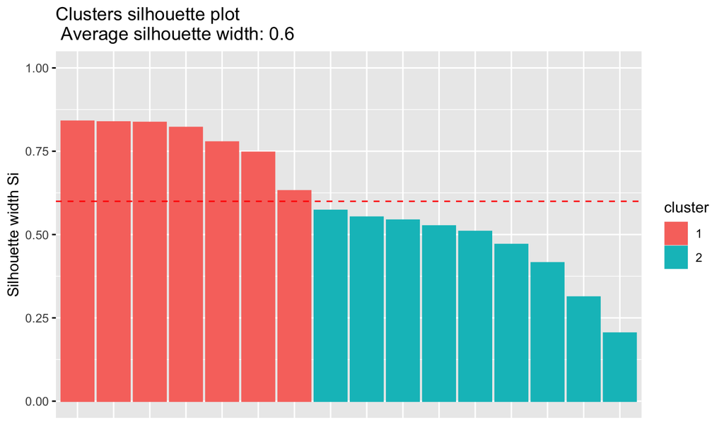

```r
wine.agnes = eclust(scaled.df,
       FUNcluster = "agnes",
       k = 2 ,
       hc_metric = "euclidean", hc_method = "ward.D2", # Distance metric and aglomeration method
       seed = 888)

# Silhouette plot
fviz_silhouette(wine.agnes)
```

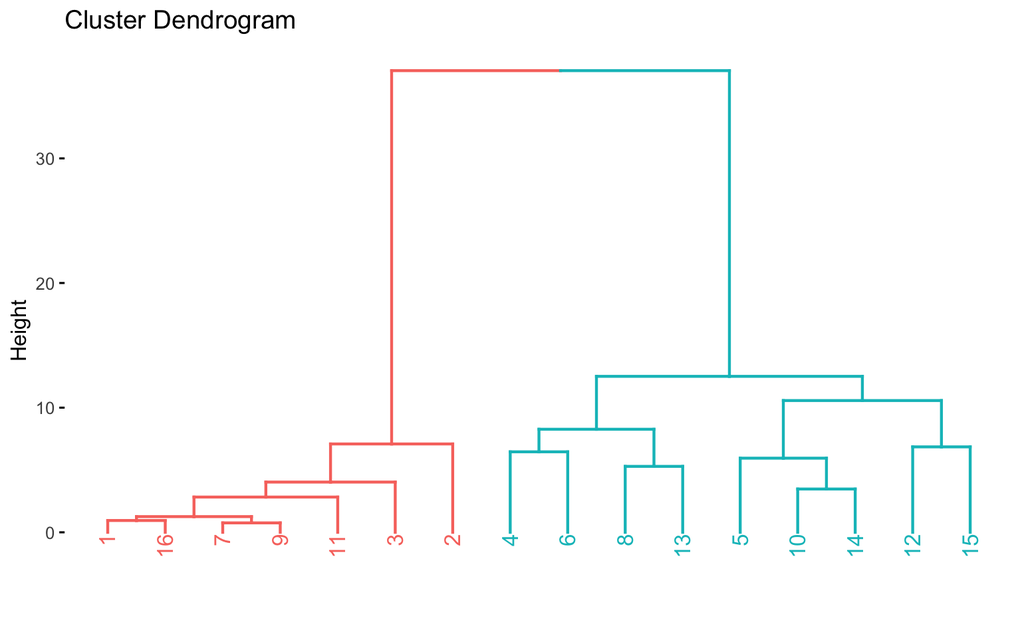

```r
# Dendrogam plot
fviz_dend(wine.agnes)
```

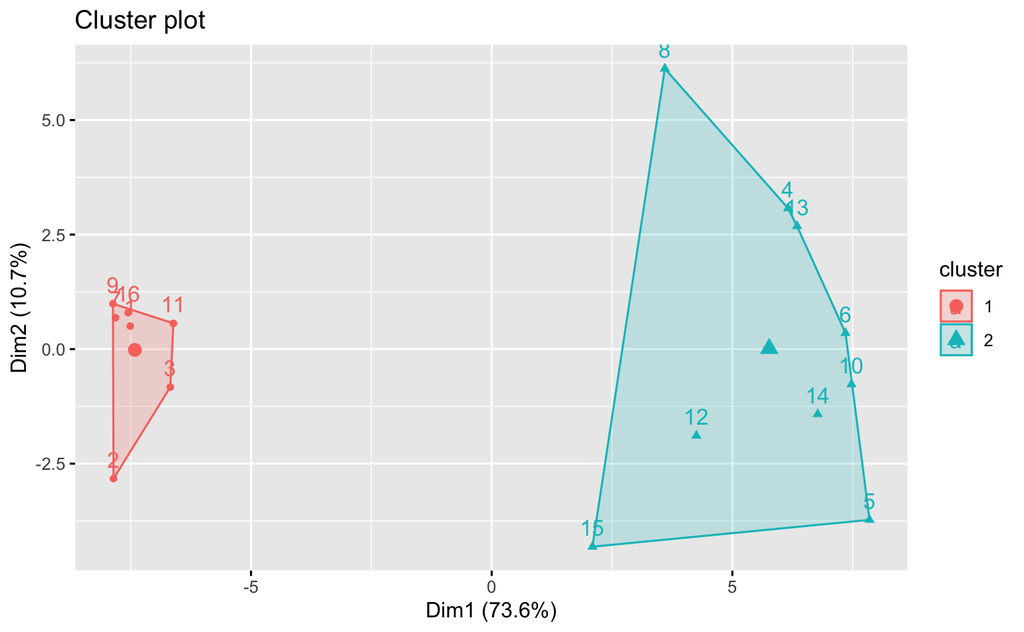

```r
# Plot cluster membership in PCA space
fviz_cluster(wine.agnes)
```

## Estimate cluster membership with UMAP-transformed data

UMAP reduces the dimensionality of the data by combining the number of columns. It can create a low-dimensional representation where similar cases are near each other.

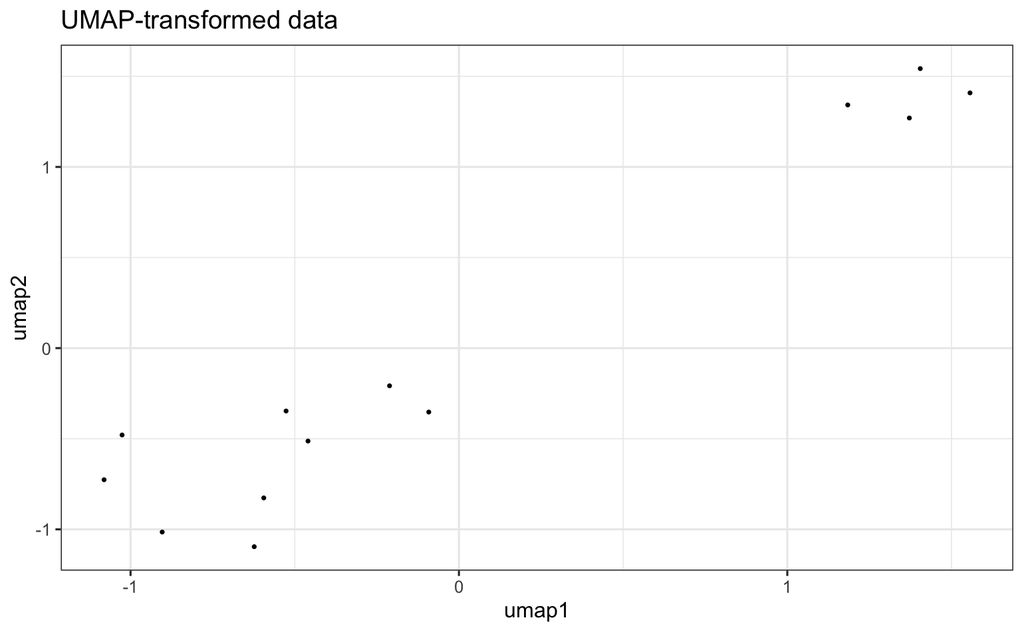

```r
## Apply umap to data
umap.df = umap(scaled.df, n_neighbors = 3, n_components = 2) %>% scale()
colnames(umap.df) = c("umap1", "umap2")
umap.df = as.data.frame(umap.df)

umap.plot = ggplot(umap.df, aes(umap1, umap2)) +
  geom_point(size = .5) +
  labs(title = "UMAP-transformed data") +
  theme_bw()
umap.plot
```

```r
sample.scaled.wine.df = cbind(scaled.df, umap.df)

## More components capture more information
umap4.df = umap(scaled.df, n_neighbors = 3, n_components = 4) %>% scale()

## Cluster based on UMAP data
internal.cl = clValid(umap4.df,
                  nClust = 2:12,
                  clMethods = c("kmeans", "pam", "agnes", "diana"),
                  maxitems = 1700,
                  validation = "internal")
```

```
rownames for data not specified, using 1:nrow(data)
```

```r
## View internal metrics
summary(internal.cl)
```

```
Clustering Methods:
 kmeans pam agnes diana

Cluster sizes:
 2 3 4 5 6 7 8 9 10 11 12

Validation Measures:
                           2       3       4       5       6       7       8       9      10      11      12

kmeans Connectivity   6.2825 13.5171 16.3266 19.4099 22.7433 26.7433 27.5766 29.5766 31.5766 34.0766 36.0766
       Dunn           1.6995  0.4526  0.5254  0.5937  0.7041  0.7585  1.1163  1.0056  0.9362  1.5253  1.2624
       Silhouette     0.8199  0.6957  0.5958  0.4847  0.3946  0.3699  0.3312  0.2625  0.2205  0.1869  0.1153
pam    Connectivity   6.2825 13.5171 16.8504 19.4933 22.5766 24.9099 27.5766 29.5766 31.5766 34.0766 36.0766
       Dunn           1.6995  0.4526  0.3800  0.3985  0.4738  0.6753  1.1163  1.0056  0.9362  1.5253  1.2624
       Silhouette     0.8199  0.6957  0.6043  0.3862  0.3156  0.3272  0.3312  0.2625  0.2205  0.1869  0.1153
agnes  Connectivity   6.2825 13.5171 16.3266 19.4099 22.7433 24.9099 27.5766 29.5766 31.5766 34.0766 36.0766
       Dunn           1.6995  0.4526  0.5254  0.5937  0.7041  0.6753  1.1163  1.0056  0.9362  1.5253  1.2624
       Silhouette     0.8199  0.6957  0.5958  0.4847  0.3946  0.3272  0.3312  0.2625  0.2205  0.1869  0.1153
diana  Connectivity   6.2825 13.5171 16.3266 19.4099 22.7433 24.9099 27.5766 29.5766 32.0766 34.0766 36.0766
       Dunn           1.6995  0.4526  0.5254  0.5937  0.7041  0.6753  1.1163  1.0056  0.6732  1.5253  1.2624
       Silhouette     0.8199  0.6957  0.5958  0.4847  0.3946  0.3272  0.3312  0.2625  0.2289  0.1869  0.1153

Optimal Scores:
```

|  | Score | Method | Clusters |
| --- | --- | --- | --- |
| Connectivity | 6.2825 | kmeans | 2 |
| Dunn | 1.6995 | kmeans | 2 |
| Silhouette | 0.8199 | kmeans | 2 |

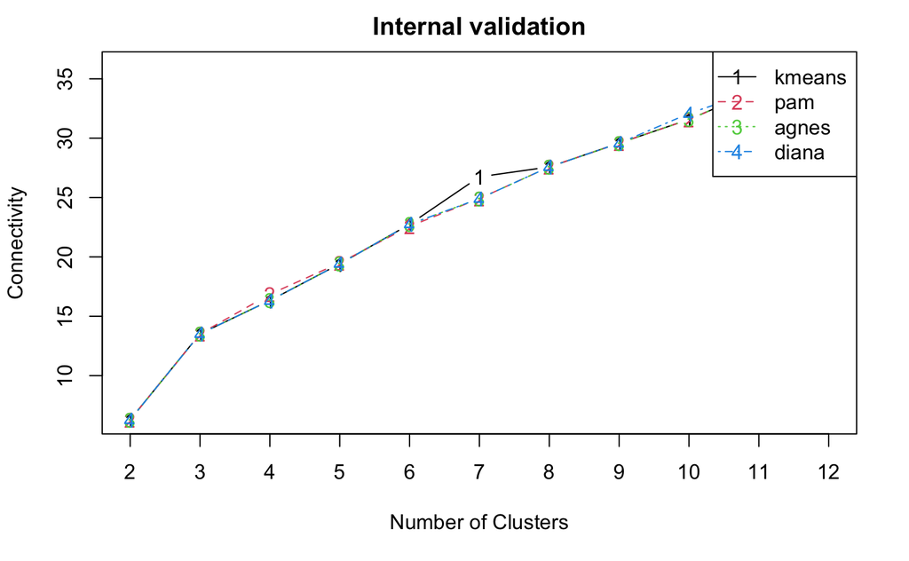

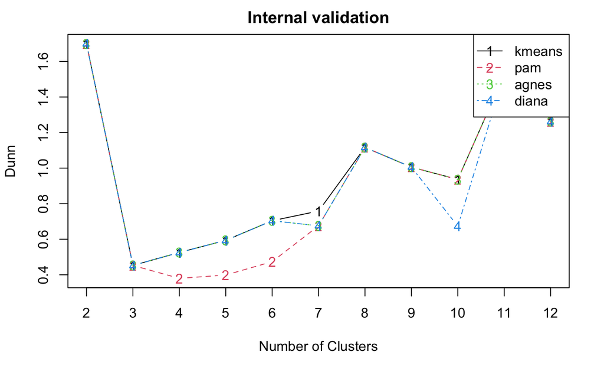

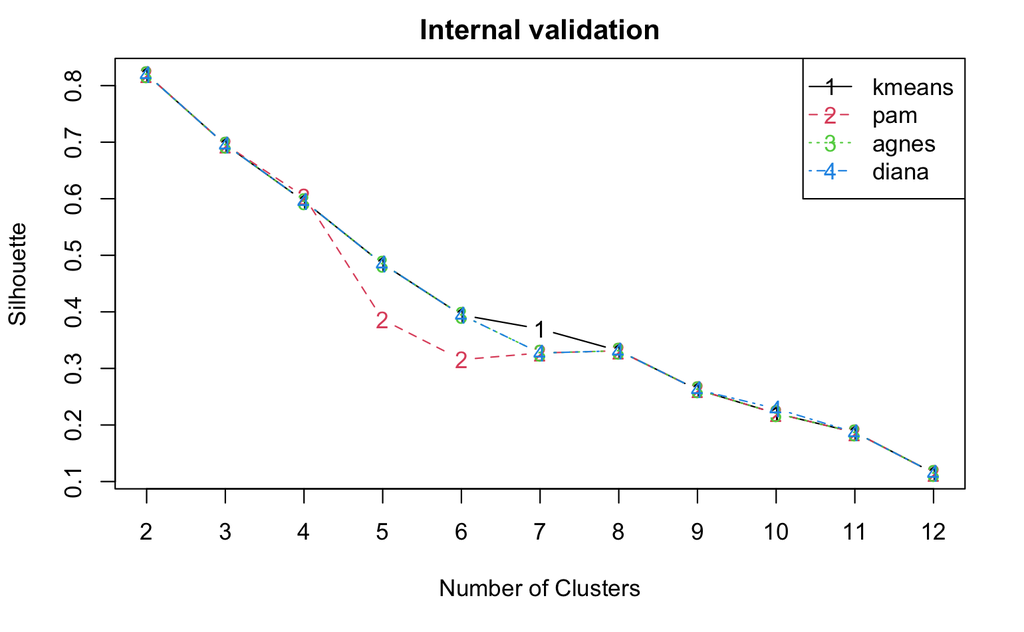

```r
plot(internal.cl)
```

```r
## Cluster based on UMAP data
stability.cl = clValid(umap4.df,
                  nClust = 2:12,
                  clMethods = c("kmeans", "pam", "agnes", "diana"),
                  maxitems = 1700,
                  validation = "stability")
```

```
rownames for data not specified, using 1:nrow(data)
```

```r
## View internal metrics
summary(stability.cl)
```

```
Clustering Methods:
 kmeans pam agnes diana

Cluster sizes:
 2 3 4 5 6 7 8 9 10 11 12

Validation Measures:
                 2      3      4      5      6      7      8      9     10     11     12

kmeans APN  0.0000 0.0750 0.1128 0.1378 0.1506 0.1154 0.0962 0.0769 0.0577 0.0385 0.0385
       AD   0.6289 0.3981 0.3517 0.3096 0.2550 0.2082 0.1495 0.0996 0.0756 0.0408 0.0208
       ADM  0.0000 0.0919 0.1065 0.1139 0.1229 0.1042 0.0799 0.0518 0.0466 0.0284 0.0171
       FOM  0.1990 0.1954 0.2040 0.2137 0.2216 0.2306 0.2063 0.1505 0.1668 0.1417 0.1356
pam    APN  0.0000 0.0750 0.0904 0.1000 0.1122 0.1058 0.0962 0.0769 0.0577 0.0385 0.0385
       AD   0.6289 0.3981 0.3474 0.3019 0.2346 0.1869 0.1495 0.0996 0.0756 0.0408 0.0208
       ADM  0.0000 0.0919 0.1075 0.1077 0.0775 0.0771 0.0799 0.0518 0.0466 0.0284 0.0171
       FOM  0.1990 0.1954 0.2047 0.2106 0.1842 0.1960 0.2063 0.1505 0.1668 0.1417 0.1356
agnes  APN  0.0000 0.0750 0.0872 0.1122 0.1250 0.1058 0.0962 0.0769 0.0577 0.0385 0.0385
       AD   0.6289 0.3981 0.3434 0.3013 0.2467 0.2075 0.1495 0.0996 0.0756 0.0408 0.0208
       ADM  0.0000 0.0919 0.0885 0.0959 0.1049 0.0983 0.0799 0.0518 0.0466 0.0284 0.0171
       FOM  0.1990 0.1954 0.2036 0.2132 0.2211 0.2309 0.2063 0.1505 0.1668 0.1417 0.1356
diana  APN  0.0000 0.0750 0.1103 0.1058 0.1250 0.1058 0.0962 0.0769 0.0962 0.0385 0.0385
       AD   0.6289 0.3981 0.3474 0.2975 0.2467 0.2075 0.1495 0.0996 0.0835 0.0408 0.0208
       ADM  0.0000 0.0919 0.0992 0.0957 0.1049 0.0983 0.0799 0.0518 0.0643 0.0284 0.0171
       FOM  0.1990 0.1954 0.2040 0.2083 0.2211 0.2309 0.2063 0.1505 0.1652 0.1417 0.1356

Optimal Scores:
```

|  | Score | Method | Clusters |
| --- | --- | --- | --- |
| APN | 0.0000 | kmeans | 2 |
| AD | 0.0208 | kmeans | 12 |
| ADM | 0.0000 | kmeans | 2 |
| FOM | 0.1356 | kmeans | 12 |

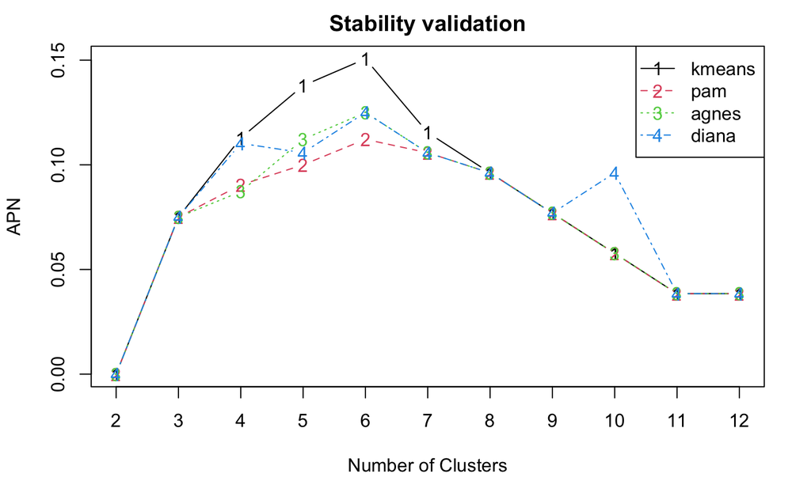

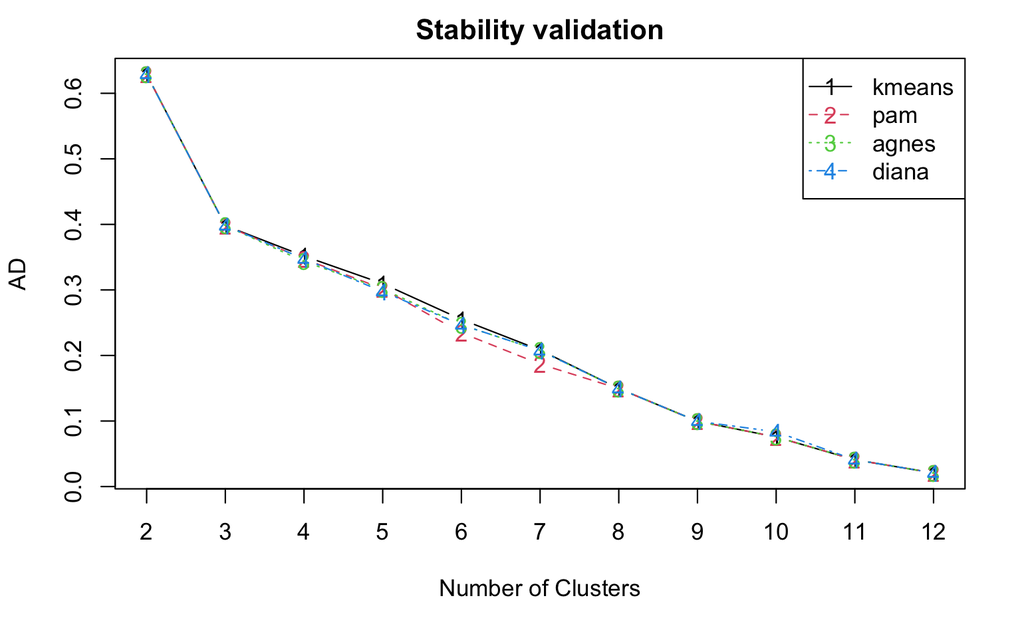

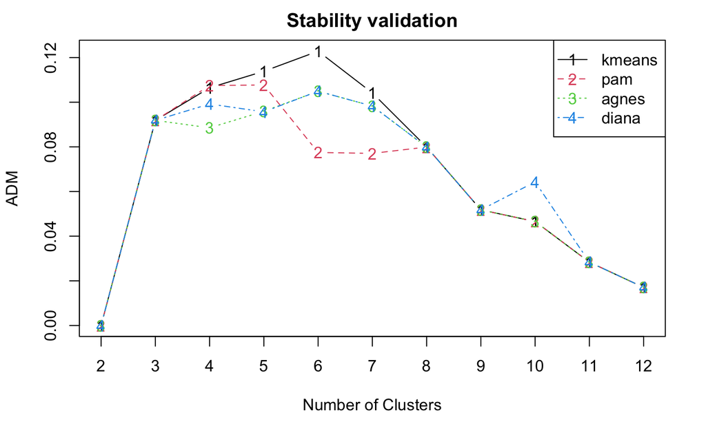

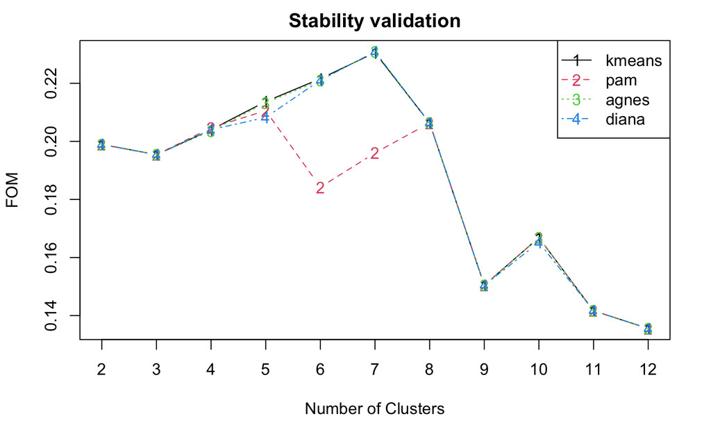

```r
plot(stability.cl)
```

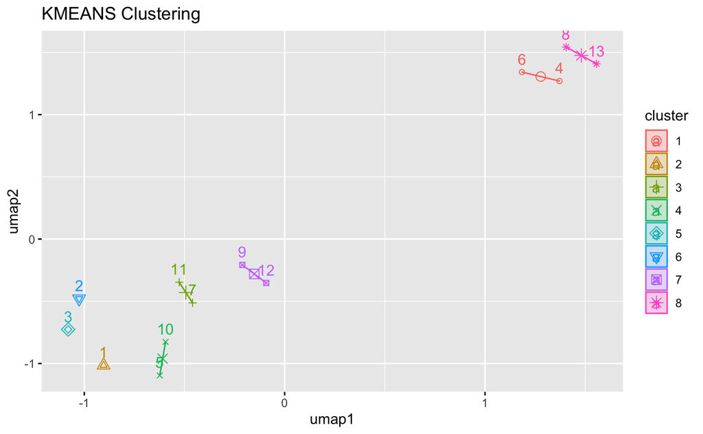

```r
## UMAP and kmeans
umap.wine.kmean = eclust(umap.df,
       FUNcluster = "kmeans",
       k = 8,
       seed = 888)
```

```r
sample.scaled.wine.df = cbind(scaled.df, cluster = as.factor(umap.wine.kmean$cluster))

print(sample.scaled.wine.df)
```

| h.asm.s1_mean | h.asm.s1_sd | h.con.s1_mean | h.con.s1_sd | h.cor.s1_mean | h.cor.s1_sd | h.var.s1_mean | h.var.s1_sd | h.idm.s1_mean | h.idm.s1_sd | h.sav.s1_mean | h.sav.s1_sd | h.sva.s1_mean | h.sva.s1_sd | h.sen.s1_mean | h.sen.s1_sd | h.ent.s1_mean | h.ent.s1_sd | h.dva.s1_mean | h.dva.s1_sd | h.den.s1_mean | h.den.s1_sd | h.f12.s1_mean | h.f12.s1_sd | h.f13.s1_mean | h.f13.s1_sd | h.asm.s2_mean | h.asm.s2_sd | h.con.s2_mean | h.con.s2_sd | … |
| --- | --- | --- | --- | --- | --- | --- | --- | --- | --- | --- | --- | --- | --- | --- | --- | --- | --- | --- | --- | --- | --- | --- | --- | --- | --- | --- | --- | --- | --- | --- |
| -0.8534937 | 0.7336460 | -0.06346644 | -0.2811650 | -0.4555575740 | 0.6306730 | 0.08257981 | -0.1525885 | -0.8529313 | 0.1366757 | -1.70420571 | 1.6350303 | -1.63229523 | 1.47908735 | 0.94097683 | 0.5674026 | 0.909011989 | 0.4358561 | -0.06346644 | -0.2811650 | 0.6378265 | 0.0325740 | -1.21415401 | -0.7654256 | -0.81406707 | 1.3082291 | -0.84512640 | 0.79481814 | -0.1369658 | -0.3641928 | … |
| 0.1731431 | 1.0511010 | 1.93677765 | 2.0489675 | -0.3108917329 | 0.4065505 | 1.62652893 | 1.5992119 | -0.7650333 | 0.8723774 | 0.27149522 | -0.1782809 | 0.22435283 | -0.08105039 | 0.42216958 | 0.9123143 | 0.527647431 | 0.8708807 | 1.93677765 | 2.0489675 | 1.1576467 | 1.1395142 | -0.97459127 | -0.1283240 | -0.92789343 | 0.2139722 | 0.08962516 | 1.13835560 | 1.8169449 | 1.9835607 | … |
| 0.1153302 | 1.3193912 | 0.41111521 | 0.5432855 | 0.4535246230 | 0.1602151 | 1.41654618 | 1.6399645 | -0.5471090 | 0.7651878 | -0.54739641 | 0.6922563 | -0.59941767 | 0.82004376 | 0.84533105 | 1.5291540 | 0.836775059 | 1.3780334 | 0.41111521 | 0.5432855 | 0.5765885 | 0.7610510 | -0.54053447 | -0.6746038 | 0.04891993 | 2.0726952 | 0.13213519 | 1.32747985 | 0.8532335 | 1.0763902 | … |
| 1.3549323 | -1.3567898 | -1.05399928 | -1.0858375 | 0.7831410413 | -0.9964205 | -1.00198168 | -1.0522488 | 1.4150338 | -1.3879259 | 0.89415911 | -0.9099839 | 0.95738241 | -0.98486808 | -1.34977704 | -1.3410541 | -1.357321780 | -1.3528009 | -1.05399928 | -1.0858375 | -1.4045936 | -1.3521861 | 1.40337991 | -0.9513928 | 0.88222146 | -0.8656706 | 1.36349984 | -1.33770149 | -1.0274827 | -1.0489991 | … |
| -0.8988561 | 0.1677353 | -0.81789630 | -0.7045966 | 0.8177531276 | -0.6838135 | -0.66833745 | -0.5485032 | 0.1267020 | 0.1252945 | -1.88338589 | 1.8942144 | -1.80103244 | 1.82829452 | 0.29660951 | 0.1957636 | 0.090757680 | 0.1331132 | -0.81789630 | -0.7045966 | -0.4244896 | -0.1218231 | 0.36877610 | 0.8152499 | 0.83563389 | -0.7496064 | -0.95181601 | 0.18377960 | -0.4868426 | -0.3118547 | … |
| 1.3573393 | -1.3567898 | -1.07795020 | -1.0858375 | 1.0096968045 | -0.9964205 | -1.00053131 | -1.0522488 | 1.3999333 | -1.3879259 | 0.89094405 | -0.9099839 | 0.95040315 | -0.98486808 | -1.28993199 | -1.3410541 | -1.313032919 | -1.3528009 | -1.07795020 | -1.0858375 | -1.3846627 | -1.3521861 | 1.43984749 | -0.9513928 | 0.98383645 | -0.8656706 | 1.35698096 | -1.33770149 | -1.0290249 | -1.0489991 | … |
| -1.5520486 | 0.1125641 | 1.27226232 | 0.7499576 | -0.4725878700 | 0.7525433 | 1.17949620 | 0.9117673 | -1.3293048 | 0.6255345 | -0.05673984 | -0.2081577 | -0.17816063 | -0.15636863 | 1.33558404 | 0.3785150 | 1.353250891 | 0.4843328 | 1.27226232 | 0.7499576 | 1.2906792 | 0.6692172 | -0.49232392 | 1.0628203 | 0.04295035 | 0.1718161 | -1.35365406 | -0.03296495 | 1.4819147 | 0.7567811 | … |
| 0.8593558 | -1.3567898 | -1.04632198 | -1.0858375 | 0.7345868268 | -0.9964205 | -0.99852922 | -1.0522488 | 1.2393457 | -1.3879259 | 0.86398270 | -0.9099839 | 0.90661557 | -0.98486808 | -1.05442222 | -1.3410541 | -1.136189882 | -1.3528009 | -1.04632198 | -1.0858375 | -1.1206355 | -1.3521861 | 0.93348239 | -0.9513928 | 0.70365426 | -0.8656706 | 0.75736014 | -1.33770149 | -0.9992843 | -1.0489991 | … |
| -0.3778008 | 0.4379730 | -0.07140018 | 0.1220933 | -1.0450757707 | 2.3844276 | -0.53992188 | -0.3691053 | -0.2912829 | 0.6851639 | 0.57951041 | -0.5299926 | 0.54606302 | -0.47753939 | -0.07219554 | 0.1630432 | 0.004989896 | 0.2660222 | -0.07140018 | 0.1220933 | 0.2193717 | 0.7541008 | -0.21459907 | 1.7922356 | -0.71109035 | 1.2701592 | -0.38035618 | 0.40279892 | -0.0156413 | 0.1855466 | … |
| -0.9261015 | 0.4038715 | 0.28954639 | 0.4278130 | 0.1225145532 | -0.3150953 | 0.38768013 | 0.5163195 | -0.5165425 | 0.7775478 | -1.06898208 | 1.0956623 | -1.11567555 | 1.15843825 | 0.94403340 | 0.8399744 | 0.878310712 | 0.9066427 | 0.28954639 | 0.4278130 | 0.5388999 | 0.7983124 | -0.08441017 | 0.9381036 | 0.50880019 | -0.7911716 | -1.02787205 | 0.39601154 | 0.5156103 | 0.7209401 | … |

[output cut: 3 more lines]

```r
# km_umap.plot =
#   ggplot(sample.scaled.wine.df, aes(umap1, umap2, colour = cluster)) +
#   geom_point(size = 1) +
#   labs(title = "Kmeans clustering based on UMAP transformed data", x = "", y = "") +
#   theme_bw() +
#   theme(legend.position = "none")
#
# km_umap.plot

## Hierarchical density based clustering is very sensitive to the minimum number of points
sample.scaled.wine.df$hdb.cluster = hdbscan(as.matrix(umap4.df), minPts = 3)$cluster %>%
  as.factor()

hdbscan.plot =
  ggplot(sample.scaled.wine.df, aes(umap1, umap2, colour = hdb.cluster)) +
  geom_point(size = 1) +
  labs(title = "HDBscan clustering based on UMAP transformed data", x = "", y = "") +
  theme_bw() +
  theme(legend.position = "none")
hdbscan.plot
```

[output not shown]

[output not shown]